# R

# R Camp in This Winter

# Live coding on Zoom

[figure not shown]

## Statistical program

- [S, S-Plus, R](https://stat.ethz.ch/~www/SandR.html)

```r
data("iris")
aov(Sepal.Length ~ Species, data = iris) |> summary()
```

```
             Df Sum Sq Mean Sq F value Pr(>F)
Species       2  63.21  31.606   119.3 <2e-16 ***
Residuals   147  38.96   0.265
---
Signif. codes:  0 '***' 0.001 '**' 0.01 '*' 0.05 '.' 0.1 ' ' 1
```

## Bioinformatics

- [Bioconductor](https://www.bioconductor.org/)
- [maftools](https://www.bioconductor.org/packages/devel/bioc/vignettes/maftools/inst/doc/maftools.html)

## Data Science

- [R4DS](https://r4ds.had.co.nz/)
- [Tidymodels](https://www.tidymodels.org/)

## Shiny (Web application)

- [NGS interpretation](http://160.1.17.93/Interpretation/)
- [NGS Data](http://160.1.17.93/cmcNgsShiny/)

## Documentation

- [Website](https://extraordinary-tulumba-269604.netlify.app/docs/)
- [Manuscript](https://pkgs.rstudio.com/rticles/)

A data analysis is **reproducible** if all the information (data, files, etc.) required is available for someone else to re-do your entire analysis. This includes:

- Data available
- All code for cleaning raw data
- All code and software (specific versions, packages) for analysis

https://geanders.github.io/RProgrammingForResearch/

Some advantages of making your research reproducible are:

- You can (easily) figure out what you did six months from now.
- You can (easily) make adjustments to code or data, even early in the process, and re-run all analysis.
- When you’re ready to publish, you can (easily) do a last double-check of your full analysis, from cleaning the raw data through generating figures and tables for the paper.
- You can pass along or share a project with others.
- You can give useful code examples to people who want to extend your research.

Some of the steps required to making research reproducible are:

- All your raw data should be saved in the project directory. You should have clear documentation on the source of all this data.
- Scripts should be included with all the code used to clean this data into the data set(s) used for final analyses and to create any figures and tables.
- You should include details on the versions of any software used in analysis (for R, this includes the version of R as well as versions of all packages used).
- If possible, there should be no “by hand” steps used in the analysis; instead, all steps should be done using code saved in scripts. For example, you should use a script to clean data, rather than cleaning it by hand in Excel. If any “non-scriptable” steps are unavoidable, you should very clearly document those steps.

## Data processing

- Data Wrangling
  - Right data form
- Data Cleaning
  - Find and correct inaccurate data
- Data Mining
  - Find meanings

## Sharing

- Documentation
  - RMarkdown
  - Quarto
- Git

## Results

```r
library(ggplot2)
iris|>
  ggplot(aes(x=Species, y=Sepal.Length))+
  geom_boxplot()+
  ylab("Sepal Length")+
  ggpubr::theme_pubclean()
```

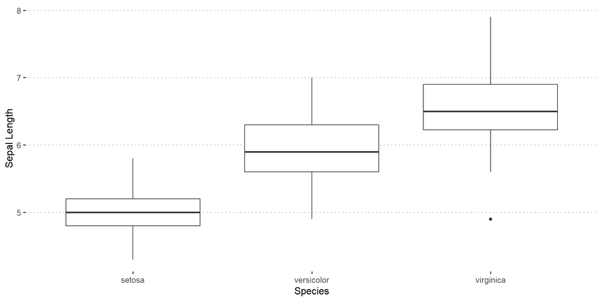

## Git

- [git](https://git-scm.com/)
- [github](https://github.com/)
- [github RLecture repository](https://github.com/Jkang-alien/RLecture)